# Exercises and Solutions - Statistics for Biology FS 2020

## Week 3 (11.03.2020)

#### Exercise 7

Load the data set “chap04e1HumanGeneLengths.csv” (the lengh of genes in the human genome, found on ilias) and answer the following questions and provide the R code you used for that. Put all of your analysis in a single R script.

1. How many individuals are in the sample (i.e., what is the sample size, n)?
2. What is the sum of all of the observations?
3. What is the mean of this sample?
4. What is the sum of the squares of the measurements?
5. What is the variance of this sample?
6. What is the standard deviation of this sample?
7. What is the coefficient of variation for this sample?
8. Display the data using different plotting techniques. Which one illustrates the data best?

###### Solutions

```r
genes <- read.csv(url("http://www.zoology.ubc.ca/~schluter/WhitlockSchluter/wp-content/data/chapter04/chap04e1HumanGeneLengths.csv"))

# a) How many individuals are in the sample (i.e., what is the sample size, n)?

n = dim(genes)[1]
print(n)
```

```
## [1] 20290
```

```r
# b)    What is the sum of all of the observations?


sum.gene.lengths = sum(genes$geneLength)

# c)    What is the mean of this sample?


mean.gene.length1 = sum.gene.lengths/n
mean.gene.length2 = mean(genes$geneLength)

print(mean.gene.length1)
```

```
## [1] 2622.027
```

```r
print(mean.gene.length2)
```

```
## [1] 2622.027
```

```r
# d)    What is the sum of the squares of the measurements?

square.sum.gene.lengths = sum(genes$geneLength^2)
print(square.sum.gene.lengths)
```

```
## [1] 223678143206
```

```r
# e)    What is the variance of this sample?

# by hand:
variance.gene.length = sum((genes$geneLength - mean.gene.length1)^2)/(n-1)

print(variance.gene.length)
```

```
## [1] 4149235
```

```r
# for comparison:
var(genes$geneLength)
```

```
## [1] 4149235
```

```r
# f)    What is the standard deviation of this sample?

sd(genes$geneLength)
```

```
## [1] 2036.967
```

```r
# or

sd.gene.length = sqrt(variance.gene.length)

# g)    What is the coefficient of variation for this sample?

cv.gene.length = sd.gene.length/mean.gene.length1
print(cv.gene.length)
```

```
## [1] 0.7768672
```

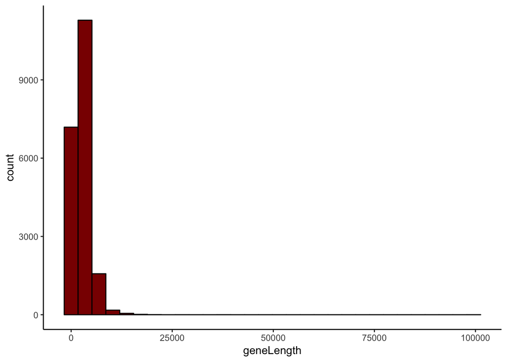

```r
# h)    Display the data using different plotting techniques. Which one illustrates the data best?

# Which one do you like best?

ggplot(data = genes) +
  geom_histogram(mapping = aes(x = geneLength),color="black",fill="darkred") +
  theme_classic()
```

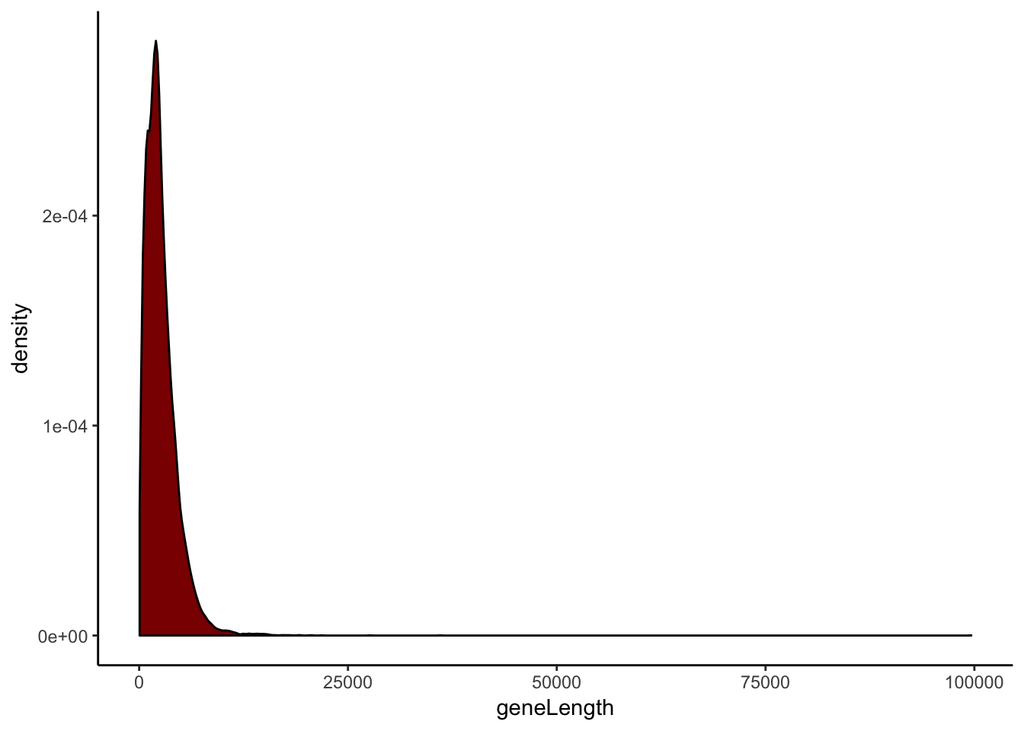

```r
ggplot(data = genes) +
  geom_density(mapping = aes(x = geneLength),color="black",fill="darkred") +
  theme_classic()
```

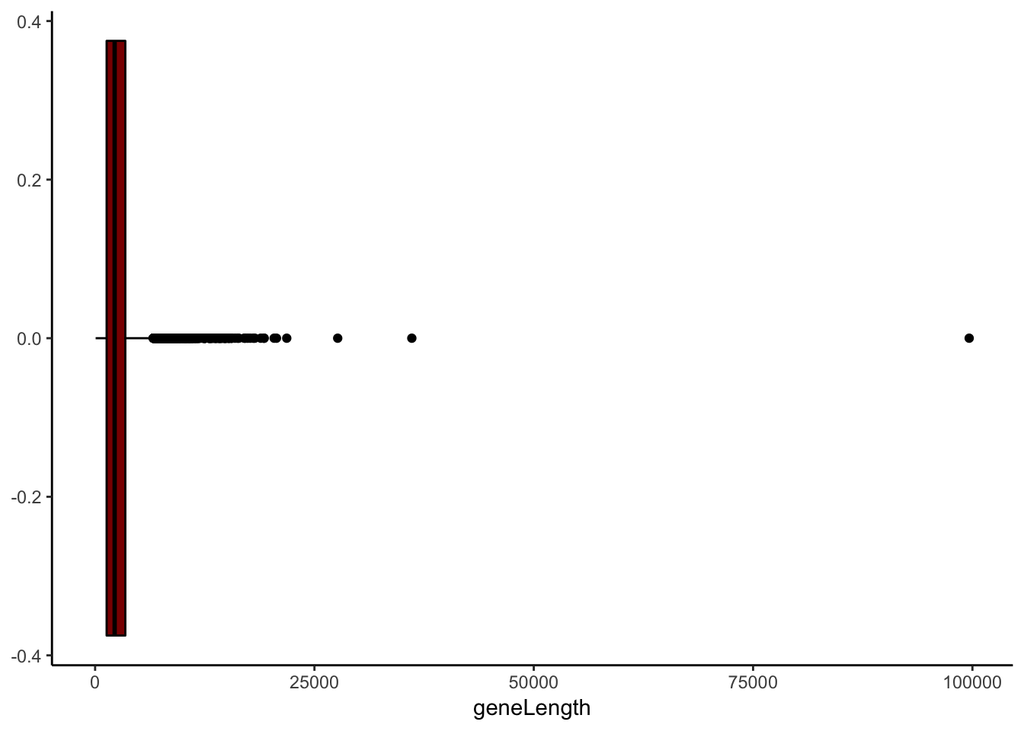

```r
ggplot(data = genes) +
  geom_boxplot(mapping = aes(y = geneLength),color="black",fill="darkred") +
  theme_classic() +
  coord_flip()
```

## Week 4 (18.03.2020)

#### Exercise 8

Use the stickleback dataset and calcualte the median and mean for each genotpye. Make a histogramm and add vertical lines to the histogramm indicating the mean and median for each genotype. What do you see? How does the shape of the distribution affect differences between mean and median?

##### Solutions

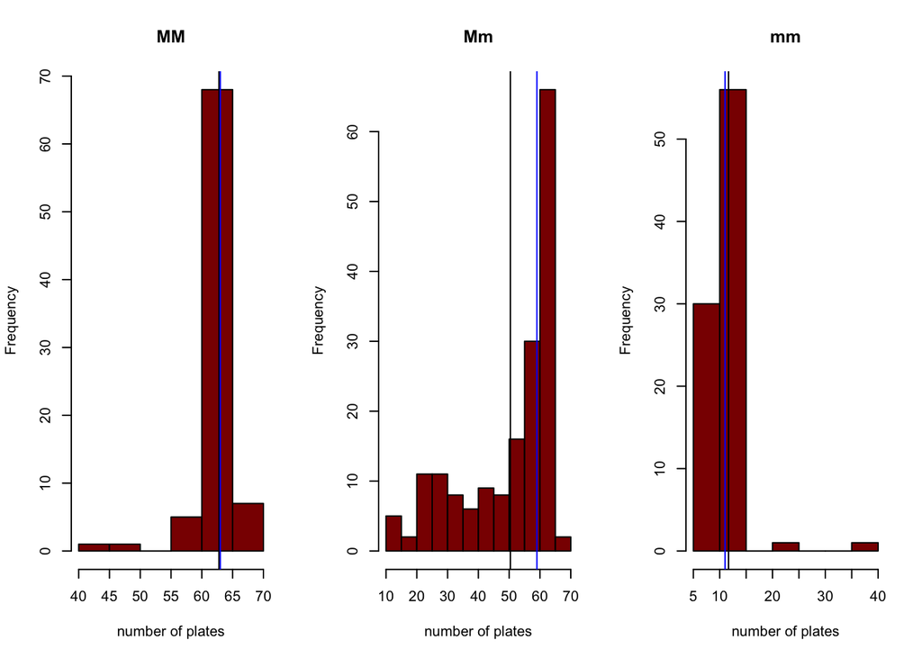

```r
# load the data file:
stickleback <- read.csv(url("http://www.zoology.ubc.ca/~schluter/WhitlockSchluter/wp-content/data/chapter03/chap03e3SticklebackPlates.csv"))

# one possible solution:

mean.mm = mean(stickleback$plates[stickleback$genotype=="mm"])
mean.mM = mean(stickleback$plates[stickleback$genotype=="Mm"])
mean.MM = mean(stickleback$plates[stickleback$genotype=="MM"])

median.mm = median(stickleback$plates[stickleback$genotype=="mm"])
median.mM = median(stickleback$plates[stickleback$genotype=="Mm"])
median.MM = median(stickleback$plates[stickleback$genotype=="MM"])

par(mfrow = c(1,3))

hist(stickleback$plates[stickleback$genotype=="MM"],
     main = "MM",xlab = "number of plates",
     col="darkred")

abline(v = mean.MM,col="black")
abline(v = median.MM,col="blue")

hist(stickleback$plates[stickleback$genotype=="Mm"],
     main = "Mm",xlab = "number of plates",
     col="darkred")
abline(v = mean.mM,col="black")
abline(v = median.mM,col="blue")

hist(stickleback$plates[stickleback$genotype=="mm"],
     main = "mm",xlab = "number of plates",
     col="darkred")
abline(v = mean.mm,col="black")
abline(v = median.mm,col="blue")
```

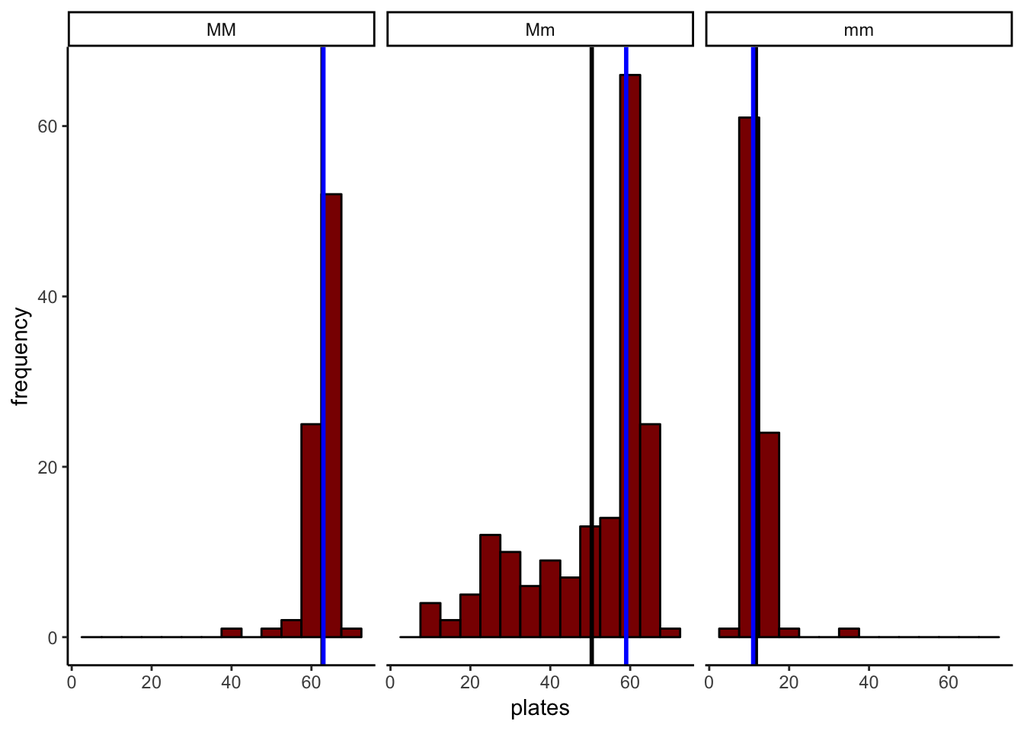

```r
# alternatively, we can first create a data frame
# with the means per genotype
# check out the help function of ddply
# (this is only one way to do this, you can also do it by
# "hand" or using other functions such as tapply) :

library(dplyr)
df.mean = ddply(stickleback, "genotype", summarize, m.number = mean(plates))
df.median = ddply(stickleback, "genotype", summarize, m.number = median(plates))

# then we plot it with a single ggplot
ggplot() +
  geom_bar(data = stickleback, mapping = aes(x=plates),binwidth=5,color="black",fill="darkred") +
  geom_vline(data = df.mean, aes(xintercept=m.number),col="black",size=1) +
  geom_vline(data = df.median, aes(xintercept=m.number),col="blue",size = 1) +
  facet_wrap(~ genotype) +
  ylab("frequency") +
  theme_classic()
```

#### Exercise 9

Write a short R script that simulates the sampling distribution of the mean. Plot the sampling distribution and add the theoretical expectation to the plot. Follow the following steps:

1. Choose a distribution that represents your population (e.g., Normal or Poisson).
2. Draw a sample of n individuals from that population (hint: use rnorm, rpoiss, etc.. to draw a random sample), and store it in a vector.
3. Calculate the mean of the sample. Store the mean of this sample in a vector.
4. Do this 1000 times, so that you have calculated a 1000 means from a 1000 samples. Hint: use a for-loop to automate this.
5. Plot a histogram of the sample means.
6. Add a line for the theoretical expectation of the sampling distribution. Hint: use the function dnorm to get the density of the normal distribution.

##### Solutions

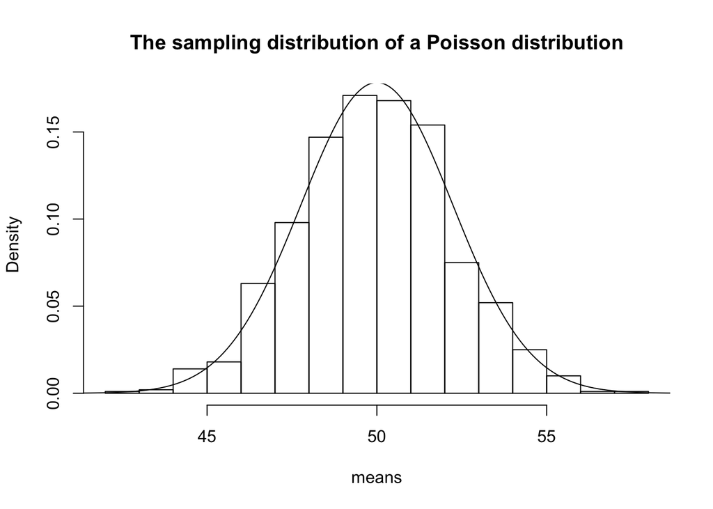

```r
# We choose the Poisson distribution with mean lambda = 50
lambda = 50

# We do 1000 replicates
reps = 1000

# We choose the sample size n to be 10
sample_size = 10

# the means of each sample will be stroed in this vector
means = vector("numeric",reps)

# in this loop, we will calcualte the means of the sample
for (i in 1:reps)
{
  # take a sample of the poisson distribution
  sample = rpois(sample_size,lambda)

  # store the mean in our vector
  means[i] = mean(sample)
}

# a histogram - note that we set freq = FALSE to
# show realtive frequencies
hist(means,freq=F,main="The sampling distribution of a Poisson distribution")

# we specify the x values for the theoretical poisson
x = seq(0,3*lambda,by=0.1)

#we calcualte the standard error:
SE = sqrt(lambda)/sqrt(sample_size)

# caclualte the corresponding PDF of the poisson
y = dnorm(x,lambda,SE)

lines(x,y)
```

## Week 5 (25.03.2020)

#### Exercise 10

The pizza below, ordered from the Venn Pizzeria on Bayes Street, is divided into eight slices.

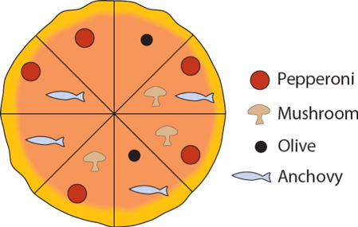

Figure: Venn Pizza

Answer the following questions based on the drawing of the pizza: a) What is the probability that a randomly drawn slice has pepperoni on it? b) What is the probability that a randomly drawn slice has both pepperoni and anchovies on it? c) What is the probability that a randomly drawn slice has either pepperoni or anchovies on it? d) Are pepperoni and anchovies mutually exclusive on this pizza? e) Are olives and mushrooms mutually exclusive on this pizza? f) Are getting mushrooms and getting anchovies independent when randomly picking a slice of pizza? g) If I pick a slice from this pizza and tell you that it has olives on it, what is the chance that it also has anchovies? h) If I pick a slice from this pizza and tell you that it has anchovies on it, what is the chance that it also has olives? i) Seven of your friends each choose a slice at random and eat them without telling you what toppings they had. What is the chance that the last slice has olives on it? j) You choose two slices at random. What is the chance that they have both olives on them? (Be careful ??? after removing the first slice, the probability of choosing one of the remaining slices changes.) k) What???s the probability that a randomly chosen slice does not have pepperoni on it? Draw a pizza for which mushrooms, olives, anchovies and pepperoni are all mutually exclusive

#### Exercise 11

After graduating from your university with a biology degree, you are interviewed for a lucrative job as a snake handler in a circus sideshow. As part of your audition, you must pick up two rattlesnakes from a pit. The pit contains eight snakes, three of which have been defanged and are assumed to be harmless, but the other five are definitely still dangerous. Unfortunately budget cuts have eliminated the herpetology course from the curriculum and so you have no way of telling in advance which snakes are dangerous and which are not. You pick one snake with your left hand and one with your right.

1. What is the probability that you picked up no dangerous snakes?
2. Assume that any dangerous snake that you pick up has a probability of 0.8 of biting you. The defanged snakes do not bite. What is the chance that, in picking up your two snakes, you are bitten at least once?
3. If you picked up one snake and it didn???t bite you, what is the probability that it is defanged.

#### Exercise 12

Five different researchers independently take a random sample from the same population and calculate a 95% confidence interval for the same parameter. a) What is the probability that all five researchers have calculated an interval that includes the true value of the parameter? b) What is the probability that at least one does not include the true parameter value.

#### Exercise 13

Use the stickleback data set. Calculate a confidence interval for the mean plate numbers for each genotype. Make a plot that shows the mean and the confidence interval of each genotype.

## Week 6 (01.04.2020)

## Week 7 (08.04.2020)

## Week 8 (21.04.2020)

## Week 9 (28.04.2020)

## Week 10 (06.05.2020)

## Week 11 (13.05.2020)

## Week 12 (20.05.2020)

## Week 13 (27.05.2020)